# Statistical Inference Course Project Part 1

avon guptrishi

June 18, 2018

Synopsis The project consists of two parts: 1. Simulation Exercise to explore inference 2. Basic inferential analysis using the ToothGrowth data in the R datasets package

Part 1: Simulation Exercise

The task is to investigate the exponential distribution in R and compare it with the Central Limit Theorem. The exponential distribution will be simulated in R with rexp(n,lambda) where lambda is the rate parameter. The mean of exponential distribution and the standard deviation are both 1/lambda where lambda = 0.2, and distribution of averages of 40 exponentials and will perform 1000 simulations.

Mean Comparision Sample Mean vs Theoretical Mean of the Distribution

```r
# Sample Mean
sampleMean <- mean(mean_sim_data) # Mean of sample means
print (paste("Sample Mean = ", sampleMean))
```

```
## [1] "Sample Mean =  5.02010698674351"
```

```r
# Theoretical Mean
# the expected mean of the exponential distribution of rate = 1/lambda
theoretical_mean <- (1/lambda)
print (paste("Theoretical Mean = ", theoretical_mean))
```

```
## [1] "Theoretical Mean =  5"
```

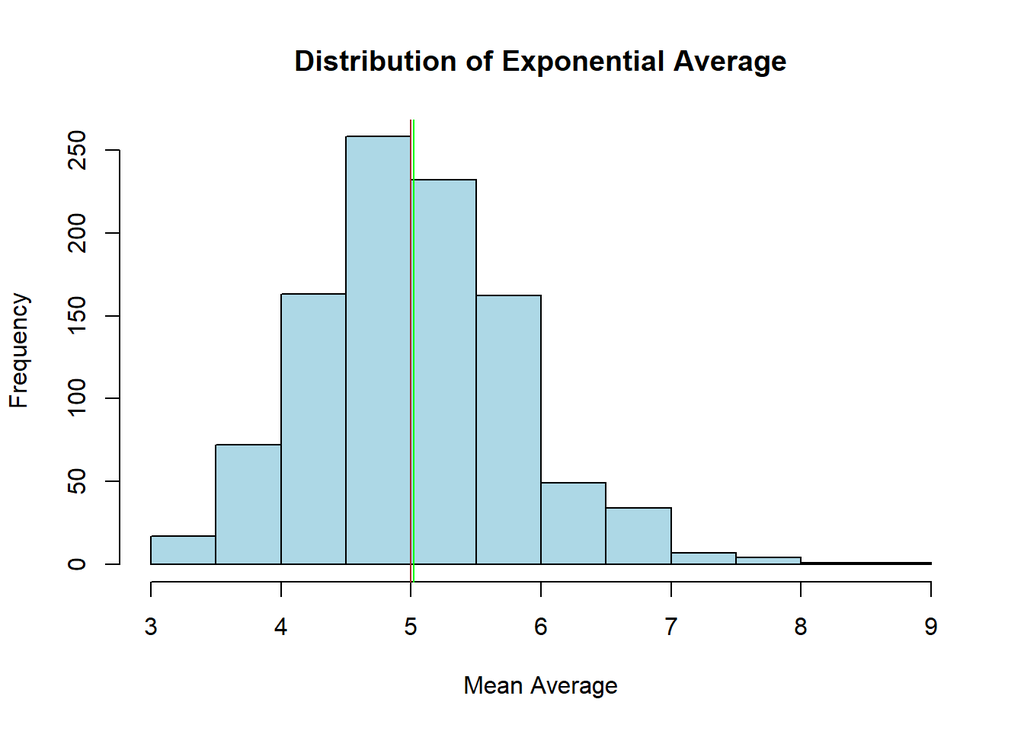

```r
# Histogram shows differences
hist(mean_sim_data, col="light blue", xlab = "Mean Average", main="Distribution of Exponential Average")
abline(v = theoretical_mean, col="brown")
abline(v = sampleMean, col="green")
```

Question 2: Show how variable the sample is (via variance) and compare it to the theoretical variance of the distribution

Calculating the theoretical and sample variance

```r
# sample deviation & variance
sample_dev <- sd(mean_sim_data)
sample_dev
```

```
## [1] 0.7912854
```

```r
sample_variance <- sample_dev^2
sample_variance
```

```
## [1] 0.6261326
```

```r
# theoretical deviation & variance
theoretical_dev <- (1/lambda)/sqrt(n)
theoretical_dev
```

```
## [1] 0.7905694
```

```r
theoretical_variance <- ((1/lambda)*(1/sqrt(n)))^2
theoretical_variance
```

```
## [1] 0.625
```

Question 3: Show that the distribution is approximately normal Histogram with Density and sample means:

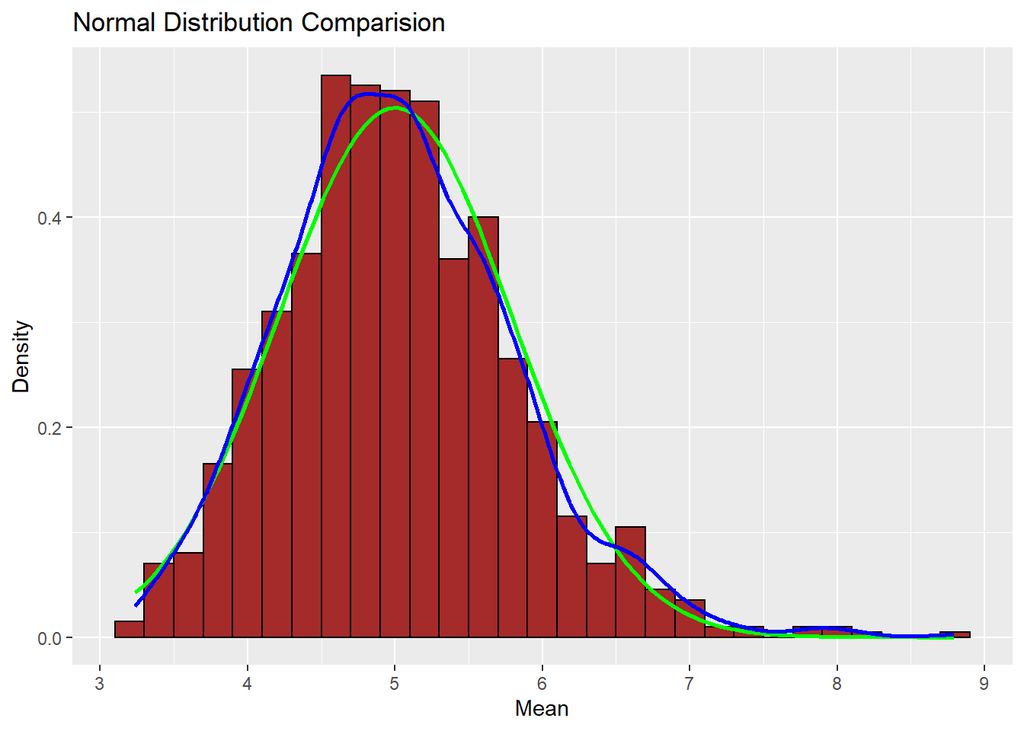

```r
d <- data.frame(mean_sim_data)
t <- data.frame(theoretical_mean)
g <- ggplot(d, aes(x = mean_sim_data)) +
 geom_histogram(binwidth = .2, color="black", fill="brown" , aes(y=..density..))+
            stat_function(fun=dnorm, args=list(mean=theoretical_mean, sd=sd(mean_sim_data)),
                          color="green", size =1) +
            stat_density(geom = "line", color = "blue", size =1)  +
            labs(x="Mean", y= "Density",
                    title="Normal Distribution Comparision")
g
```

The above plot indicated that density curve is similar to normal distribution curve.

Q-Q Normal Plot also indicates the normal distribution

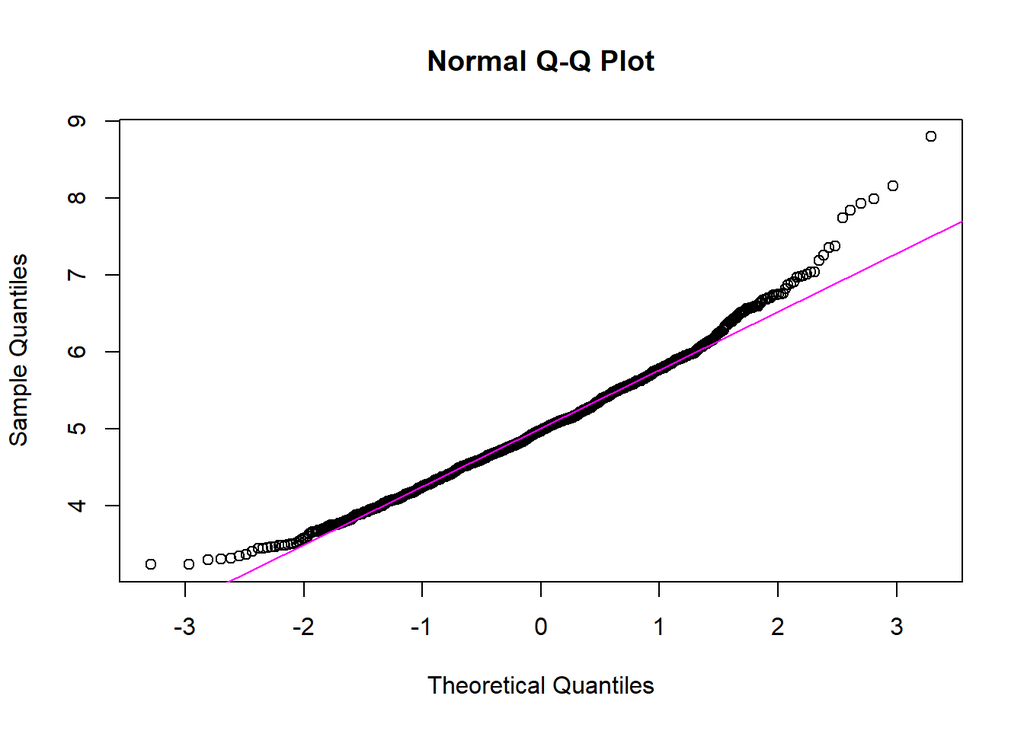

```r
qqnorm(mean_sim_data)
 qqline(mean_sim_data, col = "magenta")
```